# A Machine Learning Project for Predicting the price of the laptop given its features

## Data Cleaning, Preprocessing and Basic Data Analysis

Machine Learning or Data Analysis is performed on the data obtained from the various interactions happening around us.

Most of the times the data we collect is not pure and is instead a combination of categorical, numerical, Time-series or text data with a few inconsistent values here and there. We as humans have evolved enough to understand data in various forms and are able to establish relationships amongst them easily but then machines are not so evolved and so are unable to understand anything other than numerical data, and so we are forced to clean the data to remove inconsistencies and apply various preprocessing techniques to reduce the data into a form that is understandable by the machine.

Data cleaning or analysis and preprocessing do not tend to follow a hard fast rule of approach and is instead dependent on the type of dataset being studied, i.e approach varies for each dataset.

So always have a habit of going throught the dataset, it's meaning and significance in the real world before starting any approach.

Do tailor your approach to the dataset in hand so that proper sense can be made from the dataset.

### Importing the required libraries, files, performing basic analysis and cleaning the data

```python
# importing the required libraries

import pandas as pd
pd.set_option("display.precision", 2)
pd.set_option('display.max_columns', 500)
import matplotlib.pyplot as plt
import numpy as np
from sklearn.preprocessing import OneHotEncoder
from sklearn.preprocessing import LabelEncoder
from sklearn.preprocessing import StandardScaler
import seaborn as sns
sns.set_style('whitegrid')
from sklearn.model_selection import train_test_split, GridSearchCV
from sklearn.linear_model import LinearRegression
from sklearn.ensemble import RandomForestRegressor
from sklearn.svm import SVR
from sklearn.neighbors import KNeighborsRegressor
from sklearn.metrics import mean_absolute_error, r2_score
```

```python
# importing and reading the .csv file

df = pd.read_csv('laptop_price.csv')
print("The number of rows are", df.shape[0],"and the number of columns are", df.shape[1])
df.head()
```

```
The number of rows are 1303 and the number of columns are 13
```

|  | laptop_ID | Company | Product | TypeName | Inches | ScreenResolution | Cpu | Ram | Memory | Gpu | OpSys | Weight | Price_euros |
| --- | --- | --- | --- | --- | --- | --- | --- | --- | --- | --- | --- | --- | --- |
| 0 | 1 | Apple | MacBook Pro | Ultrabook | 13.3 | IPS Panel Retina Display 2560x1600 | Intel Core i5 2.3GHz | 8GB | 128GB SSD | Intel Iris Plus Graphics 640 | macOS | 1.37kg | 1339.69 |
| 1 | 2 | Apple | Macbook Air | Ultrabook | 13.3 | 1440x900 | Intel Core i5 1.8GHz | 8GB | 128GB Flash Storage | Intel HD Graphics 6000 | macOS | 1.34kg | 898.94 |
| 2 | 3 | HP | 250 G6 | Notebook | 15.6 | Full HD 1920x1080 | Intel Core i5 7200U 2.5GHz | 8GB | 256GB SSD | Intel HD Graphics 620 | No OS | 1.86kg | 575.00 |
| 3 | 4 | Apple | MacBook Pro | Ultrabook | 15.4 | IPS Panel Retina Display 2880x1800 | Intel Core i7 2.7GHz | 16GB | 512GB SSD | AMD Radeon Pro 455 | macOS | 1.83kg | 2537.45 |
| 4 | 5 | Apple | MacBook Pro | Ultrabook | 13.3 | IPS Panel Retina Display 2560x1600 | Intel Core i5 3.1GHz | 8GB | 256GB SSD | Intel Iris Plus Graphics 650 | macOS | 1.37kg | 1803.60 |

```python
# Checking the information of the dataframe(i.e the dataset)

df.info()
```

```
<class 'pandas.core.frame.DataFrame'>
RangeIndex: 1303 entries, 0 to 1302
Data columns (total 13 columns):
 #   Column            Non-Null Count  Dtype
---  ------            --------------  -----
 0   laptop_ID         1303 non-null   int64
 1   Company           1303 non-null   object
 2   Product           1303 non-null   object
 3   TypeName          1303 non-null   object
 4   Inches            1303 non-null   float64
 5   ScreenResolution  1303 non-null   object
 6   Cpu               1303 non-null   object
 7   Ram               1303 non-null   object
 8   Memory            1303 non-null   object
 9   Gpu               1303 non-null   object
 10  OpSys             1303 non-null   object
 11  Weight            1303 non-null   object
 12  Price_euros       1303 non-null   float64
dtypes: float64(2), int64(1), object(10)
memory usage: 132.5+ KB
```

```python
# Seeing the description of the dataframe

df.describe(include=['object', 'int64', 'float64'])
```

|  | laptop_ID | Company | Product | TypeName | Inches | ScreenResolution | Cpu | Ram | Memory | Gpu | OpSys | Weight | Price_euros |
| --- | --- | --- | --- | --- | --- | --- | --- | --- | --- | --- | --- | --- | --- |
| count | 1303.00 | 1303 | 1303 | 1303 | 1303.00 | 1303 | 1303 | 1303 | 1303 | 1303 | 1303 | 1303 | 1303.00 |
| unique | NaN | 19 | 618 | 6 | NaN | 40 | 118 | 9 | 40 | 110 | 9 | 179 | NaN |
| top | NaN | Dell | XPS 13 | Notebook | NaN | Full HD 1920x1080 | Intel Core i5 7200U 2.5GHz | 8GB | 256GB SSD | Intel HD Graphics 620 | Windows 10 | 2.2kg | NaN |
| freq | NaN | 297 | 30 | 727 | NaN | 507 | 190 | 619 | 412 | 281 | 1072 | 121 | NaN |
| mean | 660.16 | NaN | NaN | NaN | 15.02 | NaN | NaN | NaN | NaN | NaN | NaN | NaN | 1123.69 |
| std | 381.17 | NaN | NaN | NaN | 1.43 | NaN | NaN | NaN | NaN | NaN | NaN | NaN | 699.01 |
| min | 1.00 | NaN | NaN | NaN | 10.10 | NaN | NaN | NaN | NaN | NaN | NaN | NaN | 174.00 |
| 25% | 331.50 | NaN | NaN | NaN | 14.00 | NaN | NaN | NaN | NaN | NaN | NaN | NaN | 599.00 |
| 50% | 659.00 | NaN | NaN | NaN | 15.60 | NaN | NaN | NaN | NaN | NaN | NaN | NaN | 977.00 |
| 75% | 990.50 | NaN | NaN | NaN | 15.60 | NaN | NaN | NaN | NaN | NaN | NaN | NaN | 1487.88 |
| max | 1320.00 | NaN | NaN | NaN | 18.40 | NaN | NaN | NaN | NaN | NaN | NaN | NaN | 6099.00 |

```python
# Checking all the different unique values

df.nunique()
```

```
laptop_ID           1303
Company               19
Product              618
TypeName               6
Inches                18
ScreenResolution      40
Cpu                  118
Ram                    9
Memory                40
Gpu                  110
OpSys                  9
Weight               179
Price_euros          791
dtype: int64
```

The reason why we see the number of unique values for each column is to help us decide on type of encoding to use inorder to convert the catergorical values into a form understandable by the machine.

For example generally label encoding is used if there are too many categorical values and one-hot encoding if there are less categorical values, the reason for which lies in the means each method encodes the values.

One-hot encoding tends to create one less than the number of unique categories (to prevent dummy variable trap) available in the column and more the unique values more the columns and more the chance of overfitting the model while label encoding tends to label each category based on the amount of importance it has, which works best inside a column and begins affecting the accuracy, incase you use it for many columns.

So a combination of such encoding techniques would have to be used to obtain a model with really good accuracy.

```python
# Checking the number of null/missing values in the dataframe

print(df.isnull().sum())
```

```
laptop_ID           0
Company             0
Product             0
TypeName            0
Inches              0
ScreenResolution    0
Cpu                 0
Ram                 0
Memory              0
Gpu                 0
OpSys               0
Weight              0
Price_euros         0
dtype: int64
```

This is done to see the effectiveness of the dataset, more missing values means the dataset is a bad one.

If incase there are little missing values we simple replace them with mean, median or many other such values after selecting the best one.

```python
# Checking the number of 0 values in the dataframe

df = df.replace(0.0, np.nan)
df.isnull().sum()
```

```
laptop_ID           0
Company             0
Product             0
TypeName            0
Inches              0
ScreenResolution    0
Cpu                 0
Ram                 0
Memory              0
Gpu                 0
OpSys               0
Weight              0
Price_euros         0
dtype: int64
```

This is not necessary but then after a through study of Laptop Sales data, we can tell with confidence that no value is supposed to be 0 and so we perform this check.

### Now let's go through each and every column, performing the proper preprocessing techniques and analysis of the column

#### Let's start with the Company of the Laptops

```python
# Here we see all the companies who have produced Laptops

df['Company'].unique()
```

```
array(['Apple', 'HP', 'Acer', 'Asus', 'Dell', 'Lenovo', 'Chuwi', 'MSI',
       'Microsoft', 'Toshiba', 'Huawei', 'Xiaomi', 'Vero', 'Razer',
       'Mediacom', 'Samsung', 'Google', 'Fujitsu', 'LG'], dtype=object)
```

```
Dell         297
Lenovo       297
HP           274
Asus         158
Acer         103
MSI           54
Toshiba       48
Apple         21
Samsung        9
Razer          7
Mediacom       7
Microsoft      6
Xiaomi         4
Vero           4
LG             3
Fujitsu        3
Chuwi          3
Google         3
Huawei         2
Name: Company, dtype: int64
```

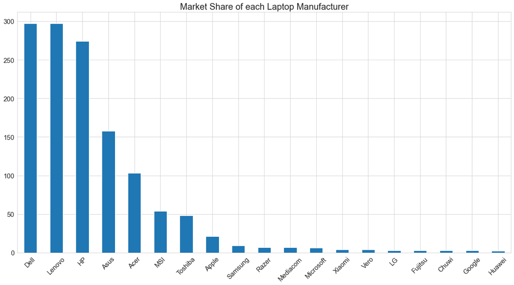

```python
# Here we see the number of laptops sold by each company

plt.title("Market Share of each Laptop Manufacturer", fontsize=20)
df['Company'].value_counts().plot(kind = 'bar', rot = 45, sort_columns = True, figsize = (20,10), fontsize = 15)
df['Company'].value_counts()
```

```
Dell         22.79
Lenovo       22.79
HP           21.03
Asus         12.13
Acer          7.90
MSI           4.14
Toshiba       3.68
Apple         1.61
Samsung       0.69
Razer         0.54
Mediacom      0.54
Microsoft     0.46
Xiaomi        0.31
Vero          0.31
LG            0.23
Fujitsu       0.23
Chuwi         0.23
Google        0.23
Huawei        0.15
Name: Company, dtype: float64
```

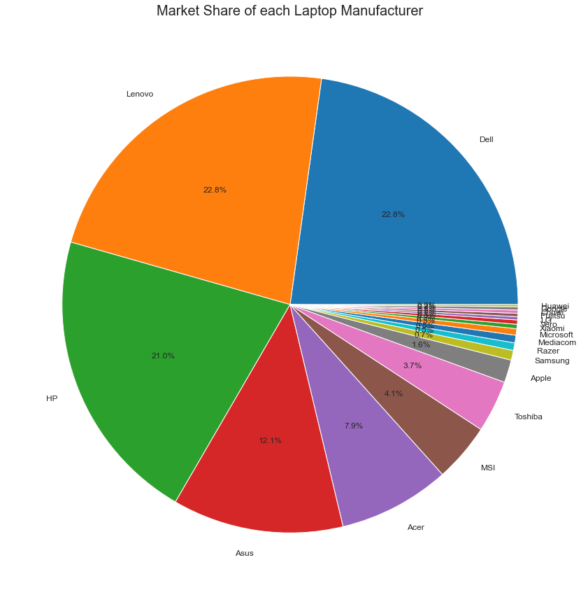

```python
# Same as that of before but as a percentage pie-chart

plt.title("Market Share of each Laptop Manufacturer", fontsize=20)
df['Company'].value_counts().plot(kind = 'pie', autopct='%1.1f%%', figsize = (20,15), fontsize = 12).set_ylabel('')
df['Company'].value_counts(normalize = True)*100
```

From the above we can see that Dell and Lenovo have the most share in the market followed by HP, Asus, Acer and so on. This shows that Dell and Lenovo have a good brand value and a loyal customer base, this information is helpful to merchants so that they can stock more laptops made by Dell and Lenovo.

#### Now let's move on to the Laptop Types

```python
# Here we see all the different types of Laptops available

df['TypeName'].unique()
```

```
array(['Ultrabook', 'Notebook', 'Netbook', 'Gaming', '2 in 1 Convertible',
       'Workstation'], dtype=object)
```

```
Notebook              727
Gaming                205
Ultrabook             196
2 in 1 Convertible    121
Workstation            29
Netbook                25
Name: TypeName, dtype: int64
```

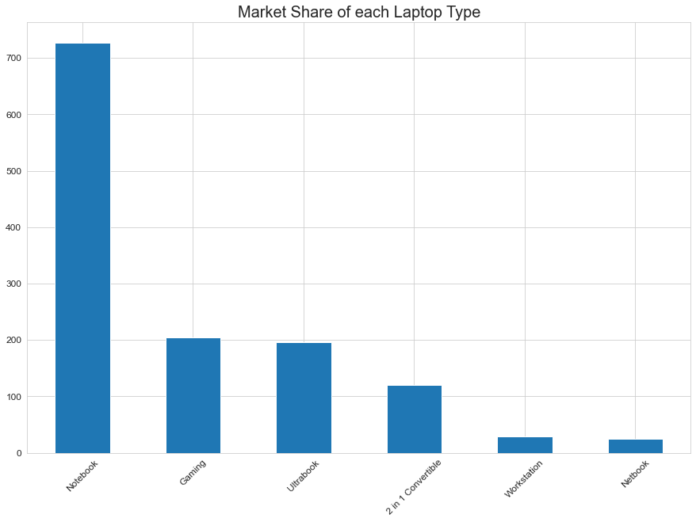

```python
# Here we see the number of laptops of each type sold

plt.title("Market Share of each Laptop Type", fontsize=20)
df['TypeName'].value_counts().plot(kind = 'bar', rot = 45, sort_columns = True, figsize = (15,10), fontsize = 12)
df['TypeName'].value_counts()
```

```
Notebook              55.79
Gaming                15.73
Ultrabook             15.04
2 in 1 Convertible     9.29
Workstation            2.23
Netbook                1.92
Name: TypeName, dtype: float64
```

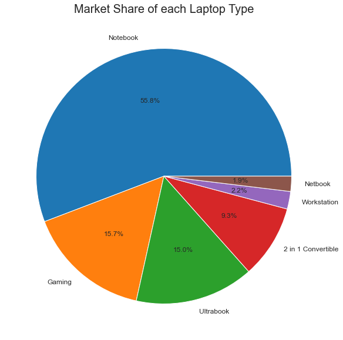

```python
# Same as that of before but as a percentage pie-chart

plt.title("Market Share of each Laptop Type", fontsize=20)
df['TypeName'].value_counts().plot(kind = 'pie', autopct='%1.1f%%', figsize = (15,10), fontsize = 12).set_ylabel('')
df['TypeName'].value_counts(normalize = True)*100
```

We can see the Notebook Laptops dominate the market by more than a 55% share followed by Gaming Laptops, Ultrabook and so on. This gives us the information that people tend to prefer Laptop Notebooks over other types and we can also see that Netbooks have the lowest share.

#### Now let's see the Laptop sizes

```python
# Here we see all the different sizes of Laptops available

df['Inches'].unique()
```

```
array([13.3, 15.6, 15.4, 14. , 12. , 11.6, 17.3, 10.1, 13.5, 12.5, 13. ,
       18.4, 13.9, 12.3, 17. , 15. , 14.1, 11.3])
```

```
15.6    665
14.0    197
13.3    164
17.3    164
12.5     39
11.6     33
13.5      6
13.9      6
12.0      6
12.3      5
10.1      4
15.0      4
15.4      4
13.0      2
11.3      1
14.1      1
17.0      1
18.4      1
Name: Inches, dtype: int64
```

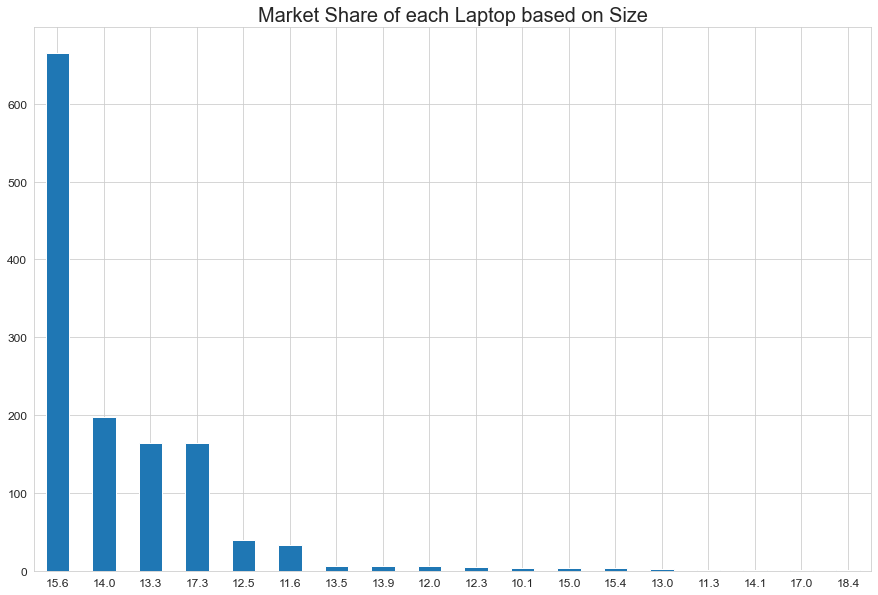

```python
# Here we see the number of laptops of each size sold

df['Inches'] = pd.to_numeric(df['Inches'])
plt.title("Market Share of each Laptop based on Size", fontsize=20)
df['Inches'].value_counts().plot(kind = 'bar', rot = 0, sort_columns = True, figsize = (15,10), fontsize = 12)
df['Inches'].value_counts()
```

```
15.6    51.04
14.0    15.12
13.3    12.59
17.3    12.59
12.5     2.99
11.6     2.53
13.5     0.46
13.9     0.46
12.0     0.46
12.3     0.38
10.1     0.31
15.0     0.31
15.4     0.31
13.0     0.15
11.3     0.08
14.1     0.08
17.0     0.08
18.4     0.08
Name: Inches, dtype: float64
```

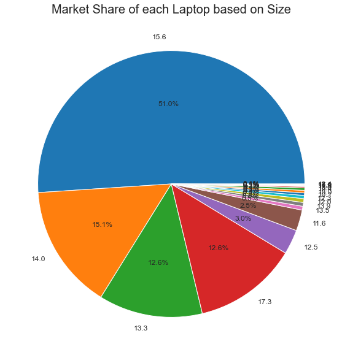

```python
# Same as that of before but as a percentage pie-chart

plt.title("Market Share of each Laptop based on Size", fontsize=20)
df['Inches'].value_counts().plot(kind = 'pie', autopct='%1.1f%%', figsize = (15,10), fontsize = 12).set_ylabel('')
df['Inches'].value_counts(normalize = True)*100
```

We can see that many people prefer a laptop size of 15.6 inches which is not so huge and yet not so small too. That is followed by 14.0 inches and so on with very less people prefering 11.3 (a little big than the smallest size available in the market) and 18.4 (the largest available size)

#### Now let us look at the Screen Resolution of the laptops

The column ScreenResolution provides an interesting problem, the data in the column is a string but also consists of a numerical data which is the screen width and height, even the data that tells us about whether the laptop has a touchscreen, OLD screen, IPS Panel or a normal screen, etc., is hidden in this column. We, on going through the values, can say what is what but a machine, unfortunately, cannot and so we must properly divide it into its individual constituents, so as to get the data into a format that can be understood by a machine.

That is exactly what we intend to do here, we first split the screen size from the data, put it into a separate column, and then we further split the screen size into its constituent width and height(effectively converting it into a numerical data).

We then go ahead by creating a separate column to specify if the laptop has a touchscreen or not.

So all in all we are splitting one column into 4 different columns thereby making the data more understandable and usable in training a model.

```python
# Here we are splitting the column of ScreenResolution into their constituent types

# First is the Screen Size

Cpu = df['ScreenResolution'].str.split()
Screen_Size = Cpu.str.get(-1)
df.insert(5, 'Screen Size', Screen_Size)
Screen_Type = []
for i in range(df.shape[0]):
    Cpu[i].remove(Screen_Size[i])
    Screen_Type.append(' '.join(Cpu[i]))
df['ScreenResolution'] = Screen_Type

# Now we are splitting the screen size into screen width and screen height

Screen = df['Screen Size'].str.split('x', expand=True)
df.insert(5, 'Screen Width', Screen[0])
df['Screen Size'] = Screen[1]
df.rename(columns={'Screen Size':'Screen Height'}, inplace=True)
df['Screen Width'] = pd.to_numeric(df['Screen Width'])
df['Screen Height'] = pd.to_numeric(df['Screen Height'])

# Creating a column known as TouchScreen to signify whether the laptop has a touch screen.

Screen = df['ScreenResolution'].str.split(' / ')
TouchScreen = []
for i in range(len(Screen)):
    if 'Touchscreen' in Screen[i] or 'IPS Panel Touchscreen' in Screen[i] or 'IPS Panel Touchscreen 4K Ultra HD' in Screen[i]:
        TouchScreen.append('Yes')
        if 'IPS Panel Touchscreen' not in Screen[i]:
            del Screen[i][Screen[i].index('Touchscreen')]
    else:
        TouchScreen.append('No')
    Screen[i] = ' '.join(Screen[i])
df.insert(8, 'TouchScreen', TouchScreen)
df['ScreenResolution'] = Screen
df['ScreenResolution'] = df['ScreenResolution'].replace('','None')
df.rename(columns={'ScreenResolution':'Screen Type'}, inplace=True)
```

```python
# displaying the dataframe with all the analysis done as of now

df.head()
```

|  | laptop_ID | Company | Product | TypeName | Inches | Screen Width | Screen Height | Screen Type | TouchScreen | Cpu | Ram | Memory | Gpu | OpSys | Weight | Price_euros |
| --- | --- | --- | --- | --- | --- | --- | --- | --- | --- | --- | --- | --- | --- | --- | --- | --- |
| 0 | 1 | Apple | MacBook Pro | Ultrabook | 13.3 | 2560 | 1600 | IPS Panel Retina Display | No | Intel Core i5 2.3GHz | 8GB | 128GB SSD | Intel Iris Plus Graphics 640 | macOS | 1.37kg | 1339.69 |
| 1 | 2 | Apple | Macbook Air | Ultrabook | 13.3 | 1440 | 900 | None | No | Intel Core i5 1.8GHz | 8GB | 128GB Flash Storage | Intel HD Graphics 6000 | macOS | 1.34kg | 898.94 |
| 2 | 3 | HP | 250 G6 | Notebook | 15.6 | 1920 | 1080 | Full HD | No | Intel Core i5 7200U 2.5GHz | 8GB | 256GB SSD | Intel HD Graphics 620 | No OS | 1.86kg | 575.00 |
| 3 | 4 | Apple | MacBook Pro | Ultrabook | 15.4 | 2880 | 1800 | IPS Panel Retina Display | No | Intel Core i7 2.7GHz | 16GB | 512GB SSD | AMD Radeon Pro 455 | macOS | 1.83kg | 2537.45 |
| 4 | 5 | Apple | MacBook Pro | Ultrabook | 13.3 | 2560 | 1600 | IPS Panel Retina Display | No | Intel Core i5 3.1GHz | 8GB | 256GB SSD | Intel Iris Plus Graphics 650 | macOS | 1.37kg | 1803.60 |

```
There are 346 laptops whose Screen Type is not available or is unspecified.
So let's perform our analysis on those laptops that have their Screen Type properly mentioned
```

```
Full HD                              555
IPS Panel Full HD                    288
IPS Panel 4K Ultra HD                 23
Quad HD+                              19
4K Ultra HD                           18
IPS Panel Retina Display              17
IPS Panel Touchscreen                 13
IPS Panel                             11
IPS Panel Quad HD+                    11
IPS Panel Touchscreen 4K Ultra HD      2
Name: Screen Type, dtype: int64
```

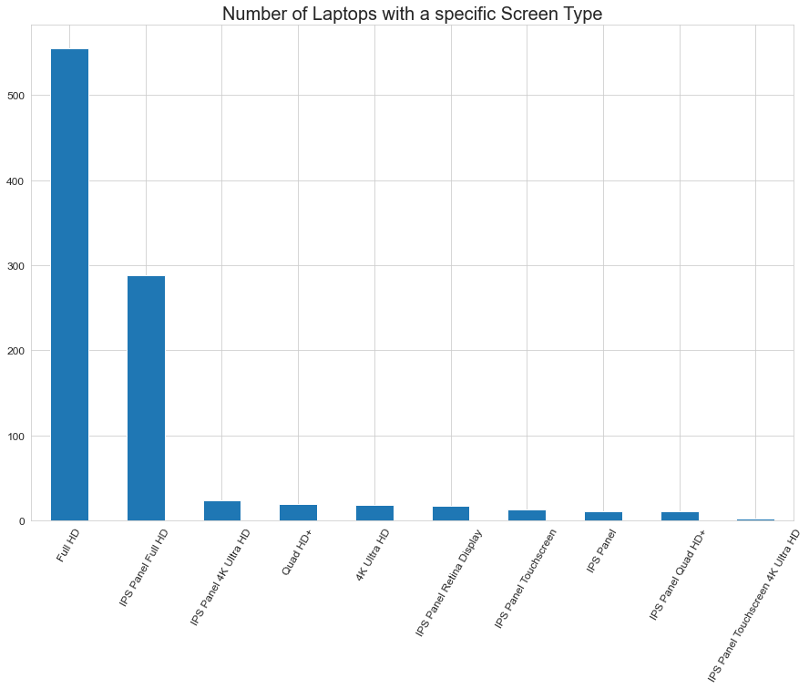

```python
# Performing our analysis on the Laptop Screen Type

print(f"There are {len(df[df['Screen Type'] == 'None'])} laptops whose Screen Type is not available or is unspecified.")
print("So let's perform our analysis on those laptops that have their Screen Type properly mentioned")
Screen_withoutNone = df[df['Screen Type'] != 'None']
plt.title("Number of Laptops with a specific Screen Type", fontsize=20)
Screen_withoutNone['Screen Type'].value_counts().plot(kind = 'bar', rot = 60, sort_columns = True, figsize = (15,10), fontsize = 12)
Screen_withoutNone['Screen Type'].value_counts()
```

```
Full HD                              57.99
IPS Panel Full HD                    30.09
IPS Panel 4K Ultra HD                 2.40
Quad HD+                              1.99
4K Ultra HD                           1.88
IPS Panel Retina Display              1.78
IPS Panel Touchscreen                 1.36
IPS Panel                             1.15
IPS Panel Quad HD+                    1.15
IPS Panel Touchscreen 4K Ultra HD     0.21
Name: Screen Type, dtype: float64
```

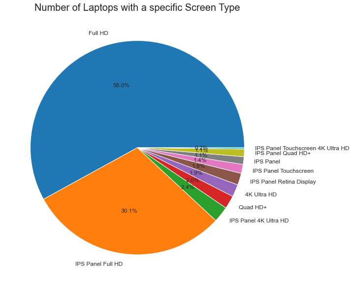

```python
# Same as that of before but as a percentage pie-chart

plt.title("Number of Laptops with a specific Screen Type", fontsize=20)
Screen_withoutNone['Screen Type'].value_counts().plot(kind = 'pie', autopct='%1.1f%%', figsize = (15,10), fontsize = 12).set_ylabel('')
Screen_withoutNone['Screen Type'].value_counts(normalize = True)*100
```

We can see that laptops with Full HD screens, having a market share of around 58%, are more preferred by the people followed by laptops with IPS Panel Full HD screens, having a market share of around 30.1% over others with IPS Panel Touchscreen 4K Ultra HD being the least preferred, and this may be due to the huge cost of such laptops.

```
No of laptops without and with touchscreens
No     1111
Yes     192
Name: TouchScreen, dtype: int64
```

```
No     85.26
Yes    14.74
Name: TouchScreen, dtype: float64
```

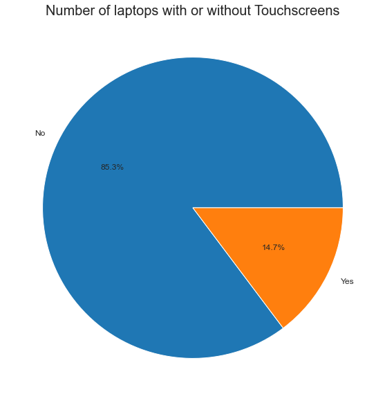

```python
# Displaying the number of laptops with and without TouchScreen

print('No of laptops without and with touchscreens')
print(df['TouchScreen'].value_counts())
plt.title("Number of laptops with or without Touchscreens", fontsize=20)
df['TouchScreen'].value_counts().plot(kind = 'pie', autopct='%1.1f%%', figsize = (15,10), fontsize = 12).set_ylabel('')
df['TouchScreen'].value_counts(normalize = True)*100
```

We can see that laptops without touchscreens dominate the market which means that people prefer laptops without touchscreen more than their counterparts.

#### Now let us look at the CPU of the laptops

The column CPU also poses the same problem as the Screen Resolution and we follow the same methods as above to split the column into 5 different columns which is easier for the machine to understand.

```python
# Here we are splitting the column of CPU into their constituent types

# First is the Cpu Vendor(i.e company that made the chipset)

Cpu_vendor = df['Cpu'].str.split(' ', 1, expand=True)
df.insert(9, 'Cpu Vendor', Cpu_vendor[0])
df['Cpu'] = Cpu_vendor[1]

# Next is the Type of the Cpu

Cpu_Type = df['Cpu'].str.split(' ', 1, expand=True)
df.insert(10, 'Cpu Type', Cpu_Type[0])
df['Cpu'] = Cpu_Type[1]

# Then we seperate the Cpu Speed

Cpu = df['Cpu'].str.split()
Cpu_speed = Cpu.str.get(-1)
df.insert(12, 'Cpu Speed', Cpu_speed)
Cpu_processor = []
for i in range(df.shape[0]):
    Cpu[i].remove(Cpu_speed[i])
    Cpu_processor.append(' '.join(Cpu[i]))
df['Cpu'] = Cpu_processor
df['Cpu Speed'] = df['Cpu Speed'].replace('[GHz]', '', regex=True)
df['Cpu Speed'] = pd.to_numeric(df['Cpu Speed'])
df.rename(columns={'Cpu Speed':'Cpu Speed (GHz)'}, inplace=True)

# Finally we divide the model and series from the column and arrange them

Cpu = list(df['Cpu'].str.split())
Cpu_model = []
Cpu_series = []
for i in Cpu:
    if len(i) == 1:
        if len(i[0].split('-')) == 2:           # this is to accomodate the data which have a '-' between the model and series
            model = i[0].split('-')
            Cpu_series.append(str(model[0]))
            Cpu_model.append(str(model[1]))
        else:
            Cpu_series.append(i[0])
            if i[0] not in ['1600', '1700']:    # this is to accomodate the Ryzen CPU whose Cpu series is dependant on the Cpu model
                Cpu_model.append('None')
            elif i[0] == '1600':
                Cpu_model.append('5')
            elif i[0] == '1700':
                Cpu_model.append('7')
    elif len(i) >= 2:
        Cpu_series.append(str(' '.join(i[:len(i)-1])))
        Cpu_model.append(str(i[-1]))
df.insert(11, 'Cpu Series', Cpu_series)
df['Cpu'] = Cpu_model
df.rename(columns={'Cpu':'Cpu Model'}, inplace=True)
```

```python
# Displaying the dataframe with all the analysis done as of now

df.head()
```

|  | laptop_ID | Company | Product | TypeName | Inches | Screen Width | Screen Height | Screen Type | TouchScreen | Cpu Vendor | Cpu Type | Cpu Series | Cpu Model | Cpu Speed (GHz) | Ram | Memory | Gpu | OpSys | Weight | Price_euros |
| --- | --- | --- | --- | --- | --- | --- | --- | --- | --- | --- | --- | --- | --- | --- | --- | --- | --- | --- | --- | --- |
| 0 | 1 | Apple | MacBook Pro | Ultrabook | 13.3 | 2560 | 1600 | IPS Panel Retina Display | No | Intel | Core | i5 | None | 2.3 | 8GB | 128GB SSD | Intel Iris Plus Graphics 640 | macOS | 1.37kg | 1339.69 |
| 1 | 2 | Apple | Macbook Air | Ultrabook | 13.3 | 1440 | 900 | None | No | Intel | Core | i5 | None | 1.8 | 8GB | 128GB Flash Storage | Intel HD Graphics 6000 | macOS | 1.34kg | 898.94 |
| 2 | 3 | HP | 250 G6 | Notebook | 15.6 | 1920 | 1080 | Full HD | No | Intel | Core | i5 | 7200U | 2.5 | 8GB | 256GB SSD | Intel HD Graphics 620 | No OS | 1.86kg | 575.00 |
| 3 | 4 | Apple | MacBook Pro | Ultrabook | 15.4 | 2880 | 1800 | IPS Panel Retina Display | No | Intel | Core | i7 | None | 2.7 | 16GB | 512GB SSD | AMD Radeon Pro 455 | macOS | 1.83kg | 2537.45 |
| 4 | 5 | Apple | MacBook Pro | Ultrabook | 13.3 | 2560 | 1600 | IPS Panel Retina Display | No | Intel | Core | i5 | None | 3.1 | 8GB | 256GB SSD | Intel Iris Plus Graphics 650 | macOS | 1.37kg | 1803.60 |

```
Intel      1240
AMD          62
Samsung       1
Name: Cpu Vendor, dtype: int64
```

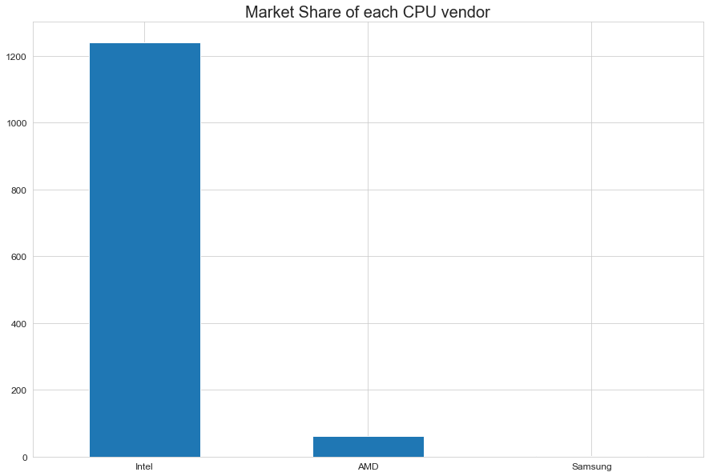

```python
# Analysing the data on Cpu Vendors

plt.title("Market Share of each CPU vendor", fontsize=20)
df['Cpu Vendor'].value_counts().plot(kind = 'bar', rot = 0, sort_columns = True, figsize = (15,10), fontsize = 12)
df['Cpu Vendor'].value_counts()
```

```
Intel      95.17
AMD         4.76
Samsung     0.08
Name: Cpu Vendor, dtype: float64
```

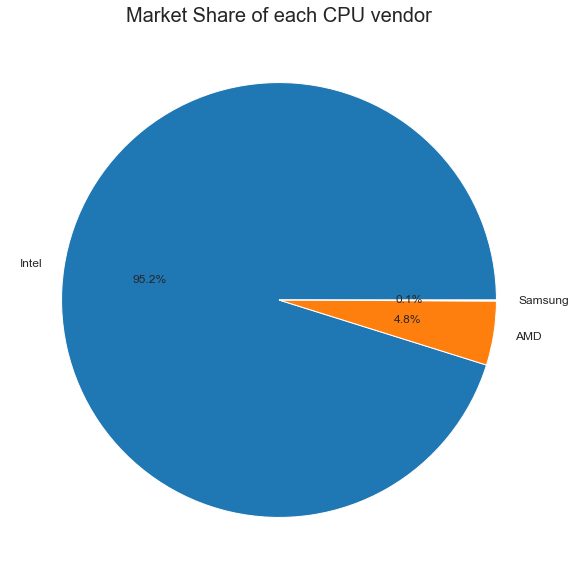

```python
# Same as that of before but as a percentage pie-chart

plt.title("Market Share of each CPU vendor", fontsize=20)
df['Cpu Vendor'].value_counts().plot(kind = 'pie', autopct='%1.1f%%', figsize = (15,10), fontsize = 12).set_ylabel('')
df['Cpu Vendor'].value_counts(normalize = True)*100
```

We can see that from the above data that Intel chipset dominate the market by about 95.2% with AMD following up with around 4.8%. We can see Samsung is the least with only 0.08%(i.e 1 laptop).

We can also see that the chipset market has only three players in total, so not much options to choose from.

```
Core          1105
Celeron         88
Pentium         30
A9-Series       17
Atom            13
A6-Series       11
E-Series         9
A12-Series       8
A10-Series       6
Xeon             4
Ryzen            4
A8-Series        4
FX               2
A4-Series        1
Cortex           1
Name: Cpu Type, dtype: int64
```

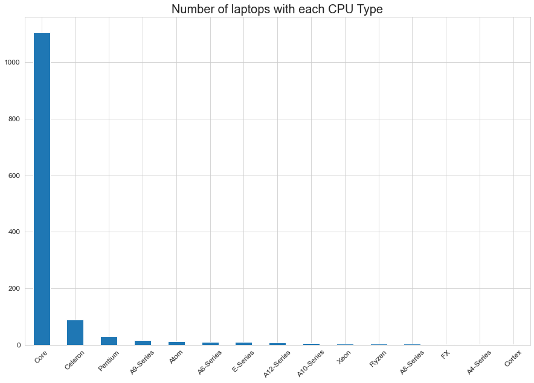

```python
# Analysing the data on Cpu Types

plt.title("Number of laptops with each CPU Type", fontsize=20)
df['Cpu Type'].value_counts().plot(kind = 'bar', rot = 45, sort_columns = True, figsize = (15,10), fontsize = 12)
df['Cpu Type'].value_counts()
```

```
Core          84.80
Celeron        6.75
Pentium        2.30
A9-Series      1.30
Atom           1.00
A6-Series      0.84
E-Series       0.69
A12-Series     0.61
A10-Series     0.46
Xeon           0.31
Ryzen          0.31
A8-Series      0.31
FX             0.15
A4-Series      0.08
Cortex         0.08
Name: Cpu Type, dtype: float64
```

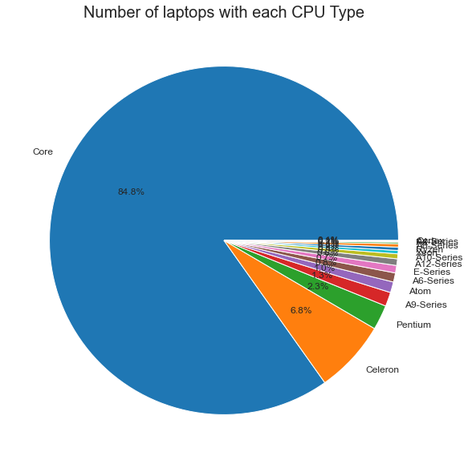

```python
# Same as that of before but as a percentage pie-chart

plt.title("Number of laptops with each CPU Type", fontsize=20)
df['Cpu Type'].value_counts().plot(kind = 'pie', autopct='%1.1f%%', figsize = (15,10), fontsize = 12).set_ylabel('')
df['Cpu Type'].value_counts(normalize = True)*100
```

We can see that the Core type has the most share and it is dominating the others by a vast majority.

```
i7           527
i5           423
i3           136
Dual Core     83
Quad Core     35
M             19
9420          12
x5            10
9220           8
9720P          7
E2             4
7410           4
1700           3
9410           3
E3-1535M       2
X5             2
A10            2
9620P          2
7110           2
9600P          2
A9             2
A6             2
E3-1505M       2
8800P          1
A72&A53        1
1600           1
9700P          1
Z8350          1
7310           1
7210           1
9830P          1
9000e          1
9000           1
6110           1
Name: Cpu Series, dtype: int64
```

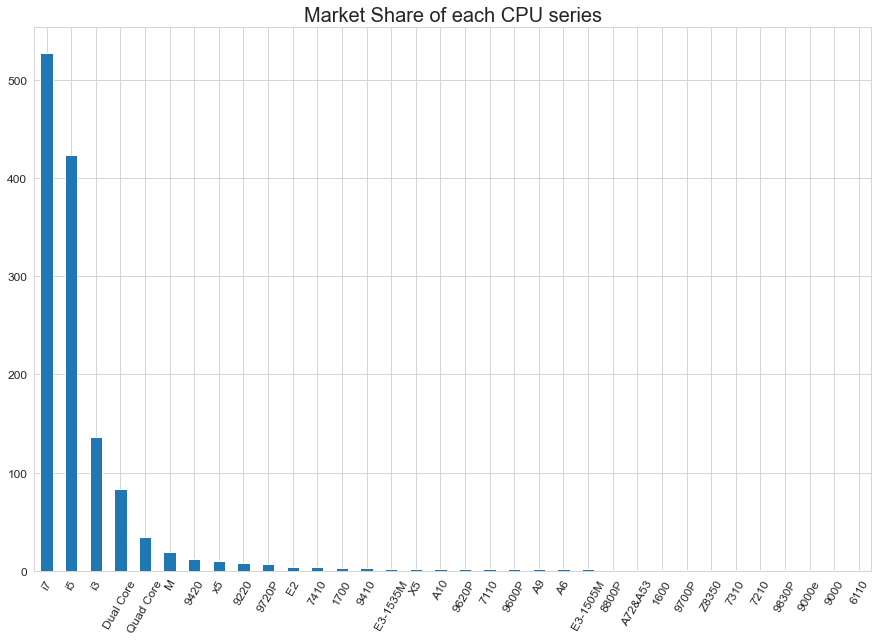

```python
# Analysing the data on Cpu Series

plt.title("Market Share of each CPU series", fontsize=20)
df['Cpu Series'].value_counts().plot(kind = 'bar', rot = 60, sort_columns = True, figsize = (15,10), fontsize = 12)
df['Cpu Series'].value_counts()
```

We can see that i7 holds the most market share followed by i5, i3, dual core, quad core and so on which seems obvious given that the majority share on the Cpu market is held by Intel.

```
There are 70 laptops whose Cpu Model is not available or is unspecified.
So let's perform our analysis on those laptops that have their Cpu Model properly mentioned
```

```
7200U     193
7700HQ    147
7500U     136
6006U      81
8550U      73
         ...
9000        1
Z8300       1
4405Y       1
m3          1
6560U       1
Name: Cpu Model, Length: 68, dtype: int64
```

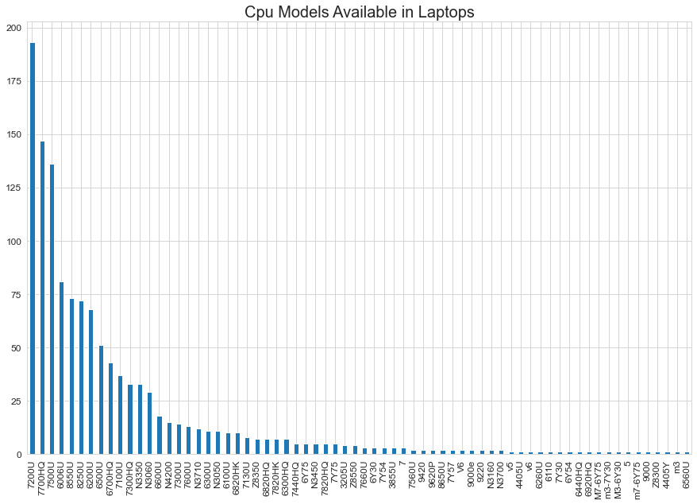

```python
# Performing analysis on the Laptop Cpu Model

print(f"There are {len(df[df['Cpu Model'] == 'None'])} laptops whose Cpu Model is not available or is unspecified.")
print("So let's perform our analysis on those laptops that have their Cpu Model properly mentioned")
Screen_withoutNone = df[df['Cpu Model'] != 'None']
plt.title("Cpu Models Available in Laptops", fontsize=20)
Screen_withoutNone['Cpu Model'].value_counts().plot(kind = 'bar', rot = 90, sort_columns = True, figsize = (15,10), fontsize = 12)
Screen_withoutNone['Cpu Model'].value_counts()
```

```python
# Analyzing the data on CPU Speed

# Displaying the unique Cpu speed values

df['Cpu Speed (GHz)'].unique()
```

```
array([2.3 , 1.8 , 2.5 , 2.7 , 3.1 , 3.  , 2.2 , 1.6 , 2.  , 2.8 , 1.2 ,
       2.9 , 2.4 , 1.44, 1.5 , 1.9 , 1.1 , 1.3 , 2.6 , 3.6 , 3.2 , 1.  ,
       2.1 , 0.9 , 1.92])
```

```python
# Displaying the maximum and minimum Cpu speed values

print('Min Cpu Speed available :- ',df['Cpu Speed (GHz)'].min(),'GHz')
print('Max Cpu Speed available :- ',df['Cpu Speed (GHz)'].max(),'GHz')
```

```
Min Cpu Speed available :-  0.9 GHz
Max Cpu Speed available :-  3.6 GHz
```

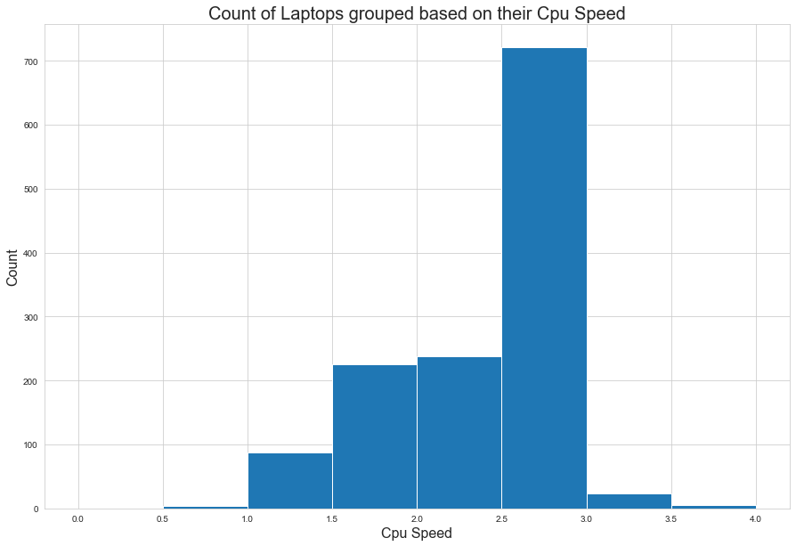

```
[0, 4, 87, 225, 238, 721, 23, 5]
```

```python
# Drawing a histogram to show the distribution of Cpu speeds

Cpu_speed = [0]*8
for i in df['Cpu Speed (GHz)']:
    Cpu_speed[int(i//0.5)] += 1
fig, ax = plt.subplots(figsize =(15,10))
ax.set_title('Count of Laptops grouped based on their Cpu Speed', fontsize=20)
ax.set_xlabel('Cpu Speed', fontsize=16)
ax.set_ylabel('Count', fontsize=16)
ax.hist(df['Cpu Speed (GHz)'], bins = [0.5*i for i in range(9)])
plt.show()
print(Cpu_speed)
```

We can see that the majority of the Cpu processers have a Cpu speed of 2.5 to 3.0, which is enough for an average user, striking a balance between cost and effeciency.

Almost all the laptops have a processor with a Cpu speed of between 1.0 to 3.0

#### Now let us look at the RAM of the laptops

```python
# Here we see all the different RAM's available

df['Ram'].unique()
```

```
array(['8GB', '16GB', '4GB', '2GB', '12GB', '6GB', '32GB', '24GB', '64GB'],
      dtype=object)
```

```
8GB     619
4GB     375
16GB    200
6GB      41
12GB     25
2GB      22
32GB     17
24GB      3
64GB      1
Name: Ram, dtype: int64
```

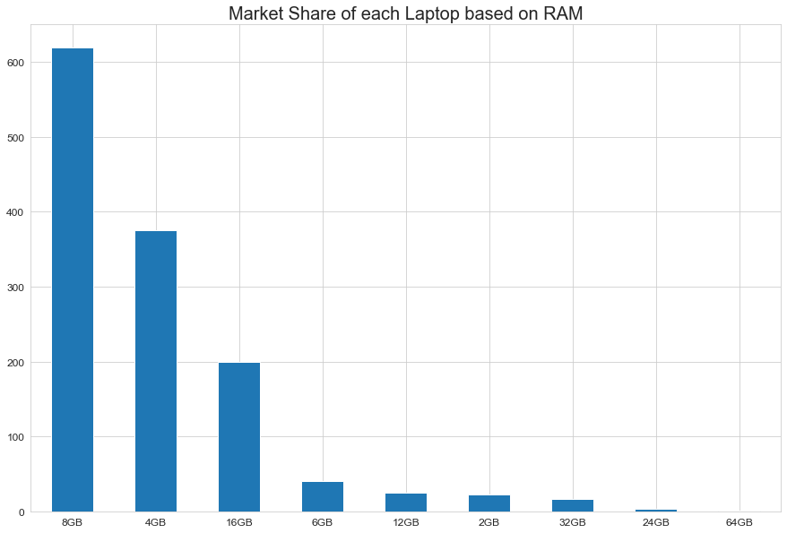

```python
# Here we are looking at the market share of each Ram

plt.title("Market Share of each Laptop based on RAM", fontsize=20)
df['Ram'].value_counts().plot(kind = 'bar', rot = 0, sort_columns = True, figsize = (15,10), fontsize = 12)
df['Ram'].value_counts()
```

```
8GB     47.51
4GB     28.78
16GB    15.35
6GB      3.15
12GB     1.92
2GB      1.69
32GB     1.30
24GB     0.23
64GB     0.08
Name: Ram, dtype: float64
```

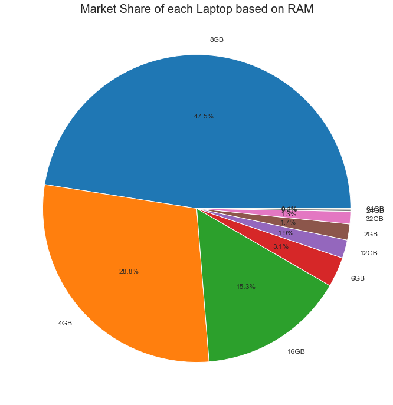

```python
# Same as that of before but as a percentage pie-chart

plt.title("Market Share of each Laptop based on RAM", fontsize=20)
df['Ram'].value_counts().plot(kind = 'pie', autopct='%1.1f%%', figsize = (15,12), fontsize = 12).set_ylabel('')
df['Ram'].value_counts(normalize = True)*100
```

We can see that most of the users perfer 8GB laptops, since they strike an balance between the price and effeciency, followed by 4GB and 16GB ones.

```python
# The value of the RAM is a string but the having it as a numerical data makes more sense and so we convert the data to a numerical one here

df['Ram'] = df['Ram'].replace('[GB]', '', regex=True)
df['Ram'] = pd.to_numeric(df['Ram'])
df.rename(columns={'Ram':'Ram (GB)'}, inplace=True)
```

#### Now let us look at the Memory of the laptops

This is another interesting column, if we observe closely we have two memory values for a few columns, this signifies that the laptop has an additional memory, also known as the secondary memory and we also have the type of memory for each memory device.

So we segregate everything into 4 different columns namely Primary Memory, Primary Memory Type, Secondary Memory and Secondary Memory Type and fill the missing values with None.

```python
# Here we are splitting the column of Memory into their constituent types

# First we are splitting the memory into Primary Memory and Seconday Memory
# We then convert Primary Memory into Primary Memory and Primary Memory Type, and do the same for Secondary Memory too

Memory = df['Memory'].str.split('+', expand = True)
for i in range(len(Memory[1])):
    if Memory[1][i] != None:
        Memory[1][i] = Memory[1][i].strip()
df.insert(16, 'Secondary Memory', Memory[1])


df['Memory'] = Memory[0]
df.rename(columns = {'Memory': 'Primary Memory'}, inplace = True)

Sec_Memory = df['Secondary Memory'].str.split(' ',1, expand = True)
df.insert(17, 'Secondary Memory Type', Sec_Memory[1])
df['Secondary Memory'] = Sec_Memory[0]

Pri_Memory = df['Primary Memory'].str.split(' ',1, expand = True)
df.insert(16, 'Primary Memory Type', Pri_Memory[1])
df['Primary Memory'] = Pri_Memory[0]

# A few values in Primary Memory and SEcondary Memory have TB in them, where 1 TB means 1024 GB, so we convert them all into GB for uniformity and
# then we convert the columns of Primary Memory and Secondary Memory into numerical values

df['Primary Memory'] = df['Primary Memory'].replace('1TB', '1024GB')
df['Primary Memory'] = df['Primary Memory'].replace('1.0TB', '1024GB')
df['Primary Memory'] = df['Primary Memory'].replace('2TB', '2048GB')
df['Primary Memory'] = df['Primary Memory'].replace('[GB]', '', regex=True)
df['Primary Memory'] = pd.to_numeric(df['Primary Memory'], downcast = 'integer')
df['Primary Memory'] = df['Primary Memory'].fillna('None')
df.rename(columns={'Primary Memory':'Primary Memory (GB)'}, inplace=True)

df['Secondary Memory'] = df['Secondary Memory'].replace('1TB', '1024GB')
df['Secondary Memory'] = df['Secondary Memory'].replace('1.0TB', '1024GB')
df['Secondary Memory'] = df['Secondary Memory'].replace('2TB', '2048GB')
df['Secondary Memory'] = df['Secondary Memory'].replace('[GB]', '', regex=True)
df['Secondary Memory'] = pd.to_numeric(df['Secondary Memory'], downcast = 'integer')
df['Secondary Memory'] = df['Secondary Memory'].fillna('None')
df.rename(columns={'Secondary Memory':'Secondary Memory (GB)'}, inplace=True)
```

```python
# Displaying the dataframe with all the analysis done as of now

df.head()
```

|  | laptop_ID | Company | Product | TypeName | Inches | Screen Width | Screen Height | Screen Type | TouchScreen | Cpu Vendor | Cpu Type | Cpu Series | Cpu Model | Cpu Speed (GHz) | Ram (GB) | Primary Memory (GB) | Primary Memory Type | Secondary Memory (GB) | Secondary Memory Type | Gpu | OpSys | Weight | Price_euros |
| --- | --- | --- | --- | --- | --- | --- | --- | --- | --- | --- | --- | --- | --- | --- | --- | --- | --- | --- | --- | --- | --- | --- | --- |
| 0 | 1 | Apple | MacBook Pro | Ultrabook | 13.3 | 2560 | 1600 | IPS Panel Retina Display | No | Intel | Core | i5 | None | 2.3 | 8 | 128 | SSD | None | None | Intel Iris Plus Graphics 640 | macOS | 1.37kg | 1339.69 |
| 1 | 2 | Apple | Macbook Air | Ultrabook | 13.3 | 1440 | 900 | None | No | Intel | Core | i5 | None | 1.8 | 8 | 128 | Flash Storage | None | None | Intel HD Graphics 6000 | macOS | 1.34kg | 898.94 |
| 2 | 3 | HP | 250 G6 | Notebook | 15.6 | 1920 | 1080 | Full HD | No | Intel | Core | i5 | 7200U | 2.5 | 8 | 256 | SSD | None | None | Intel HD Graphics 620 | No OS | 1.86kg | 575.00 |
| 3 | 4 | Apple | MacBook Pro | Ultrabook | 15.4 | 2880 | 1800 | IPS Panel Retina Display | No | Intel | Core | i7 | None | 2.7 | 16 | 512 | SSD | None | None | AMD Radeon Pro 455 | macOS | 1.83kg | 2537.45 |
| 4 | 5 | Apple | MacBook Pro | Ultrabook | 13.3 | 2560 | 1600 | IPS Panel Retina Display | No | Intel | Core | i5 | None | 3.1 | 8 | 256 | SSD | None | None | Intel Iris Plus Graphics 650 | macOS | 1.37kg | 1803.60 |

```
256     508
1024    250
128     177
512     140
500     132
32       45
64       17
2048     16
16       10
180       5
8         1
240       1
508       1
Name: Primary Memory (GB), dtype: int64
```

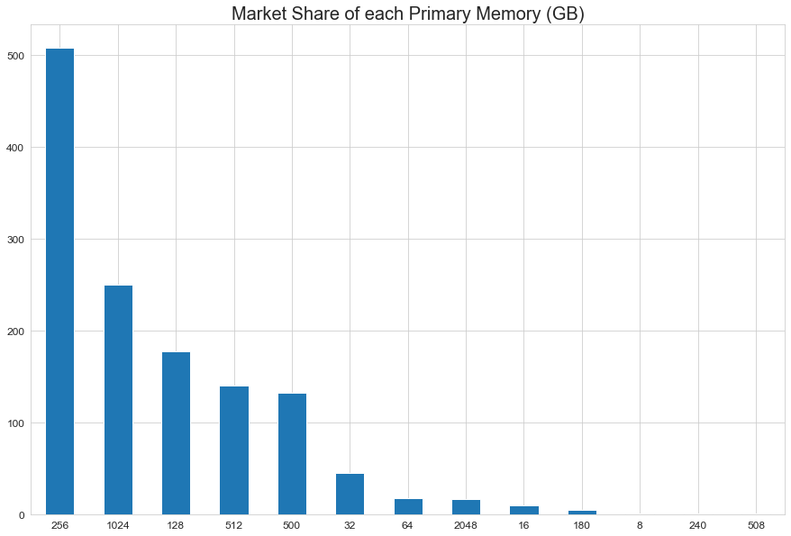

```python
# Analysing the data on memory

# Analysing the data on Primary Memory

plt.title("Market Share of each Primary Memory (GB)", fontsize=20)
df['Primary Memory (GB)'].value_counts().plot(kind = 'bar', rot = 0, sort_columns = True, figsize = (15,10), fontsize = 12)
df['Primary Memory (GB)'].value_counts()
```

```
SSD               637
HDD               374
SSD               206
Flash Storage      74
Hybrid             10
Flash Storage       1
HDD                 1
Name: Primary Memory Type, dtype: int64
```

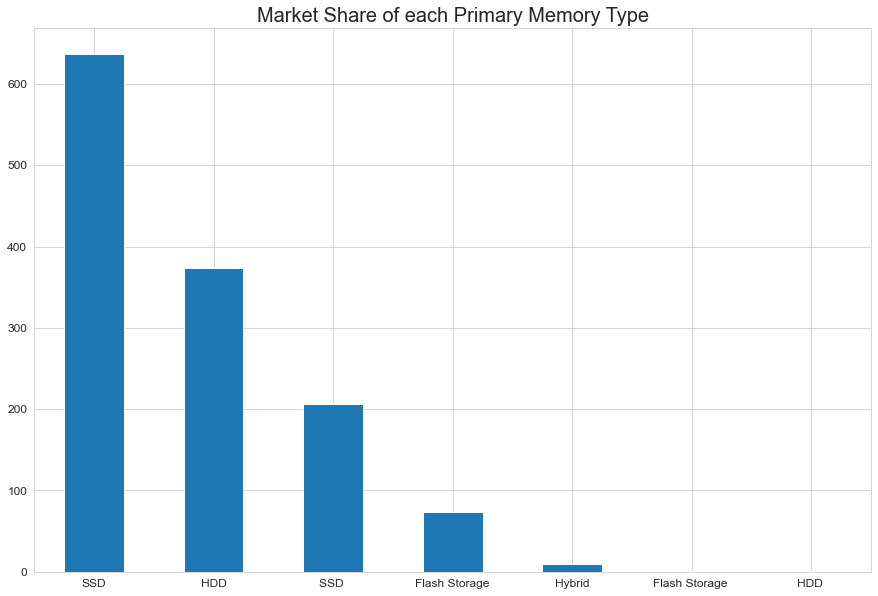

```python
# Analysing the data on Primary Memory Types

plt.title("Market Share of each Primary Memory Type", fontsize=20)
df['Primary Memory Type'].value_counts().plot(kind = 'bar', rot = 0, sort_columns = True, figsize = (15,10), fontsize = 12)
df['Primary Memory Type'].value_counts()
```

```
1024.0    187
2048.0     15
256.0       3
500.0       2
512.0       1
Name: Secondary Memory (GB), dtype: int64
```

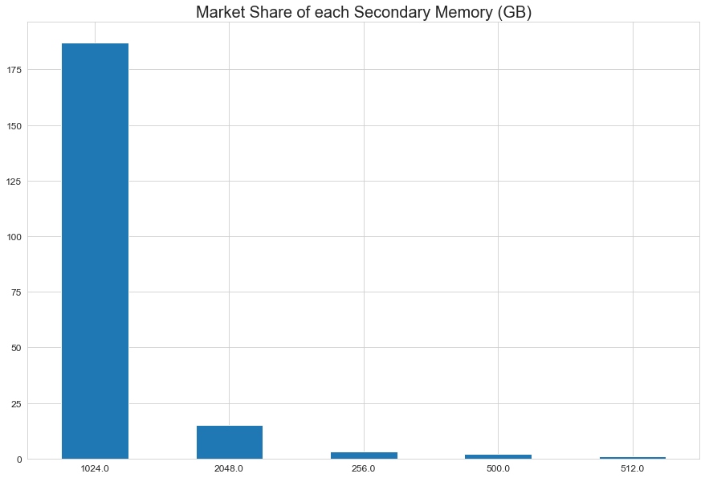

```python
# Analysing the data on Secondary Memory

plt.title("Market Share of each Secondary Memory (GB)", fontsize=20)
Secondary_memory_withoutNone = df['Secondary Memory (GB)'].replace(to_replace='None', value=np.nan).dropna()
Secondary_memory_withoutNone.value_counts().plot(kind = 'bar', rot = 0, sort_columns = True, figsize = (15,10), fontsize = 12)
Secondary_memory_withoutNone.value_counts()
```

```
HDD       202
SSD         4
Hybrid      2
Name: Secondary Memory Type, dtype: int64
```

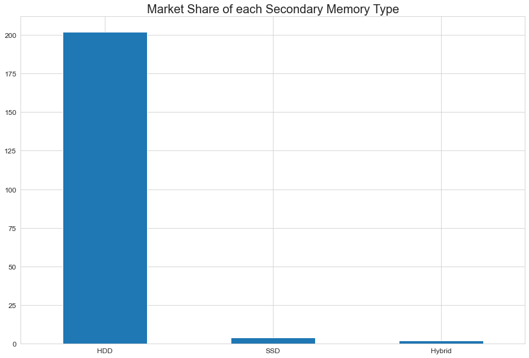

```python
# Analysing the data on Secondary Memory Types

plt.title("Market Share of each Secondary Memory Type", fontsize=20)
df['Secondary Memory Type'].value_counts().plot(kind = 'bar', rot = 0, sort_columns = True, figsize = (15,10), fontsize = 12)
df['Secondary Memory Type'].value_counts()
```

From the above bar plots we can see that 256.0 GB of SSD primary memory is the most preferred followed by 1024 GB HDD, now coming to the secondary memory we can see that not many laptops have secondary memory and in the ones that have secondary memory we can see many vendors providing 1024 GB of HDD as their secondary memory.

#### Now let us look at the GPU of the laptops

```python
# Segregating the GPU's into Gpu Vendor(i.e Gpu Manufacturer) and Gpu Model

Gpu_vendor = df['Gpu'].str.split(' ', 1, expand=True)
df.insert(19, 'Gpu Vendor', Gpu_vendor[0])
df['Gpu'] = Gpu_vendor[1]
df.rename(columns = {'Gpu': 'Gpu Model'}, inplace = True)
```

```
Intel     722
Nvidia    400
AMD       180
ARM         1
Name: Gpu Vendor, dtype: int64
```

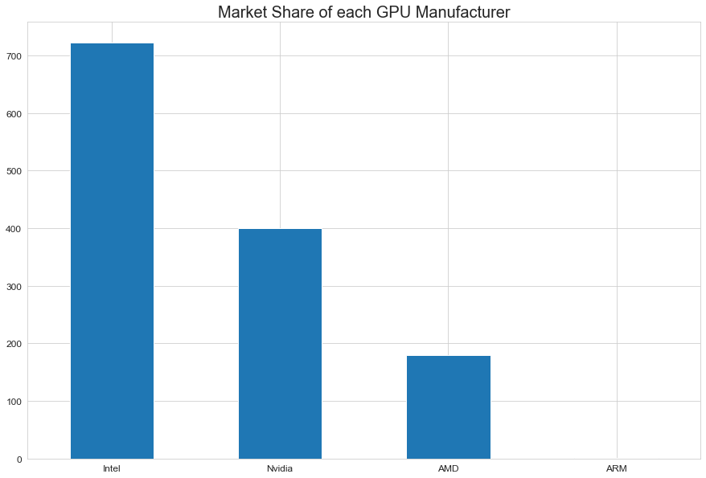

```python
# Here we are looking at the market share of each Gpu vendor

plt.title("Market Share of each GPU Manufacturer", fontsize=20)
df['Gpu Vendor'].value_counts().plot(kind = 'bar', rot = 0, sort_columns = True, figsize = (15,10), fontsize = 12)
df['Gpu Vendor'].value_counts()
```

```
Intel     55.41
Nvidia    30.70
AMD       13.81
ARM        0.08
Name: Gpu Vendor, dtype: float64
```

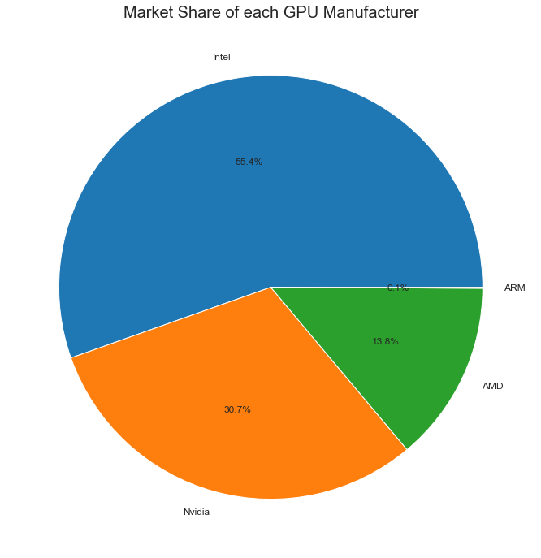

```python
# Same as that of before but as a percentage pie-chart

plt.title("Market Share of each GPU Manufacturer", fontsize=20)
df['Gpu Vendor'].value_counts().plot(kind = 'pie', autopct='%1.1f%%', figsize = (15,12), fontsize = 12).set_ylabel('')
df['Gpu Vendor'].value_counts(normalize = True)*100
```

Even in the GPU section we can see the market being dominated by Intel followed by Nvidia, the lowest being ARM.

```python
# Looking at all the different GPU Models

df['Gpu Model'].unique()
```

```
array(['Iris Plus Graphics 640', 'HD Graphics 6000', 'HD Graphics 620',
       'Radeon Pro 455', 'Iris Plus Graphics 650', 'Radeon R5',
       'Iris Pro Graphics', 'GeForce MX150', 'UHD Graphics 620',
       'HD Graphics 520', 'Radeon Pro 555', 'Radeon R5 M430',
       'HD Graphics 615', 'Radeon Pro 560', 'GeForce 940MX',
       'HD Graphics 400', 'GeForce GTX 1050', 'Radeon R2', 'Radeon 530',
       'GeForce 930MX', 'HD Graphics', 'HD Graphics 500',
       'GeForce 930MX ', 'GeForce GTX 1060', 'GeForce 150MX',
       'Iris Graphics 540', 'Radeon RX 580', 'GeForce 920MX',
       'Radeon R4 Graphics', 'Radeon 520', 'GeForce GTX 1070',
       'GeForce GTX 1050 Ti', 'GeForce MX130', 'R4 Graphics',
       'GeForce GTX 940MX', 'Radeon RX 560', 'GeForce 920M',
       'Radeon R7 M445', 'Radeon RX 550', 'GeForce GTX 1050M',
       'HD Graphics 515', 'Radeon R5 M420', 'HD Graphics 505',
       'GTX 980 SLI', 'R17M-M1-70', 'GeForce GTX 1080', 'Quadro M1200',
       'GeForce 920MX ', 'GeForce GTX 950M', 'FirePro W4190M ',
       'GeForce GTX 980M', 'Iris Graphics 550', 'GeForce 930M',
       'HD Graphics 630', 'Radeon R5 430', 'GeForce GTX 940M',
       'HD Graphics 510', 'HD Graphics 405', 'Radeon RX 540',
       'GeForce GT 940MX', 'FirePro W5130M', 'Quadro M2200M', 'Radeon R4',
       'Quadro M620', 'Radeon R7 M460', 'HD Graphics 530',
       'GeForce GTX 965M', 'GeForce GTX1080', 'GeForce GTX1050 Ti',
       'GeForce GTX 960M', 'Radeon R2 Graphics', 'Quadro M620M',
       'GeForce GTX 970M', 'GeForce GTX 960Μ', 'Graphics 620',
       'GeForce GTX 960', 'Radeon R5 520', 'Radeon R7 M440', 'Radeon R7',
       'Quadro M520M', 'Quadro M2200', 'Quadro M2000M', 'HD Graphics 540',
       'Quadro M1000M', 'Radeon 540', 'GeForce GTX 1070M',
       'GeForce GTX1060', 'HD Graphics 5300', 'Radeon R5 M420X',
       'Radeon R7 Graphics', 'GeForce 920', 'GeForce 940M',
       'GeForce GTX 930MX', 'Radeon R7 M465', 'Radeon R3',
       'GeForce GTX 1050Ti', 'Radeon R7 M365X', 'Radeon R9 M385',
       'HD Graphics 620 ', 'Quadro 3000M', 'GeForce GTX 980 ',
       'Radeon R5 M330', 'FirePro W4190M', 'FirePro W6150M',
       'Radeon R5 M315', 'Quadro M500M', 'Radeon R7 M360',
       'Quadro M3000M', 'GeForce 960M', 'Mali T860 MP4'], dtype=object)
```

Drawing a bar plot and checking the share of each model is not feasible given the number of unique models available, splitting the model into its components is also not feasible since the model names are not following a proper pattern and so we are avoiding it.

#### Now let us look at the Operating System of the laptops

```python
# Looking at all the different Operating Systems

df['OpSys'].unique()
```

```
array(['macOS', 'No OS', 'Windows 10', 'Mac OS X', 'Linux', 'Android',
       'Windows 10 S', 'Chrome OS', 'Windows 7'], dtype=object)
```

```
Windows 10      1072
No OS             66
Linux             62
Windows 7         45
Chrome OS         27
macOS             13
Windows 10 S       8
Mac OS X           8
Android            2
Name: OpSys, dtype: int64
```

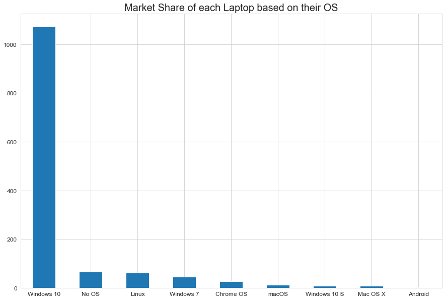

```python
# Here we are looking at the share of each OS

plt.title("Market Share of each Laptop based on their OS", fontsize=20)
df['OpSys'].value_counts().plot(kind = 'bar', rot = 0, sort_columns = True, figsize = (15,10), fontsize = 12)
df['OpSys'].value_counts()
```

```
Windows 10      82.27
No OS            5.07
Linux            4.76
Windows 7        3.45
Chrome OS        2.07
macOS            1.00
Windows 10 S     0.61
Mac OS X         0.61
Android          0.15
Name: OpSys, dtype: float64
```

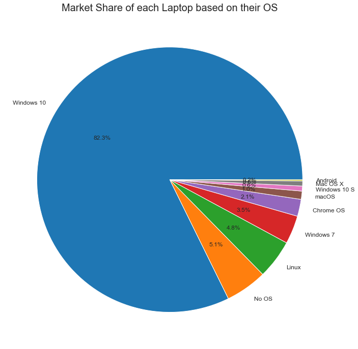

```python
# Same as that of before but as a percentage pie-chart

plt.title("Market Share of each Laptop based on their OS", fontsize=20)
df['OpSys'].value_counts().plot(kind = 'pie', autopct='%1.1f%%', figsize = (15,12), fontsize = 12).set_ylabel('')
df['OpSys'].value_counts(normalize = True)*100
```

From the above graphs we can see that Windows 10 is the OS provided by most of the vendors. It has a whopping 82.3% market share while all the others are having a minority share of 5.1%, 4.8% and so on.

#### Now let us look at the Weight of the laptops

```python
# Here we are converting the column weight with consists of strings into numeric values

df['Weight'] = df['Weight'].replace('[kg]', '', regex=True)
df['Weight'] = pd.to_numeric(df['Weight'])
df.rename(columns={'Weight':'Weight (Kg)'}, inplace=True)
```

```python
# Checking the minimum and maximum weights of laptops

print('Min weight available :- ',df['Weight (Kg)'].min(),'Kg')
print('Max weight available :- ',df['Weight (Kg)'].max(),'Kg')
```

```
Min weight available :-  0.69 Kg
Max weight available :-  4.7 Kg
```

So now we divide the laptops into seperate categories based on their weights, for this we take a range of 0.5 kgs. So if we start from 0.5 Kgs and have to go till 4.7 Kgs in intervals of 0.5 Kgs each thereby we would end up with 9 different categories.

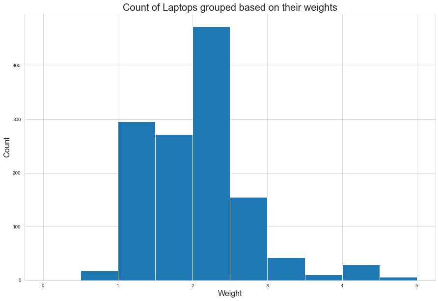

```
[0, 18, 296, 272, 473, 155, 43, 11, 29, 6]
```

```python
# Here we are grouping the weights into factors of 0.5 and plotting the number of laptops in each catergories

Weights_count = [0]*10
for i in df['Weight (Kg)']:
    Weights_count[int(i//0.5)] += 1
fig, ax = plt.subplots(figsize =(15,10))
ax.set_title('Count of Laptops grouped based on their weights', fontsize=20)
ax.set_xlabel('Weight', fontsize=16)
ax.set_ylabel('Count', fontsize=16)
ax.hist(df['Weight (Kg)'], bins = [0.5*i for i in range(11)])
plt.show()
print(Weights_count)
```

From the above histogram we can see that majority of the laptops have their weights between 1 and 3 with most falling in the range of 2 to 2.5 kgs. This makes sense given the fact that laptops being popularly known as portable computers are not so easily portable if they are heavy and 1 to 2 or 2.5 kgs is usually the sweet spot, where cost and portability strike a balance.

#### Visualizing the dataset using Heat-Map

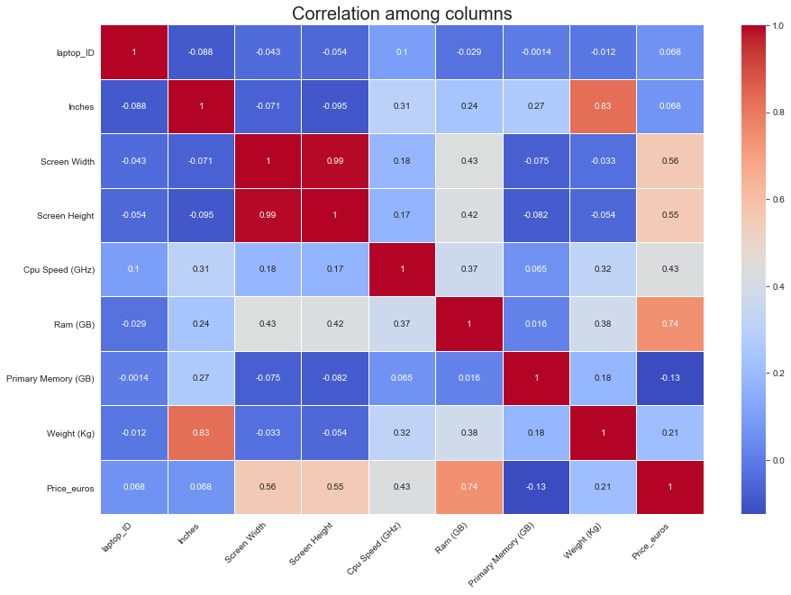

```python
# Displaying a heat-map to check the relationship between numerical features.

plt.figure()
plt.figure(figsize = (15,10))
plt.title('Correlation among columns',fontsize = 20)
laptop = sns.heatmap(df.corr(), cmap='coolwarm', annot=True, linewidths=.1)
laptop.set_xticklabels(laptop.get_xticklabels(), rotation=45, horizontalalignment='right')
plt.show()
```

### Let us see some additional analysis that can be performed on the dataset

#### Let's first look at the Average weight of each Laptop Type

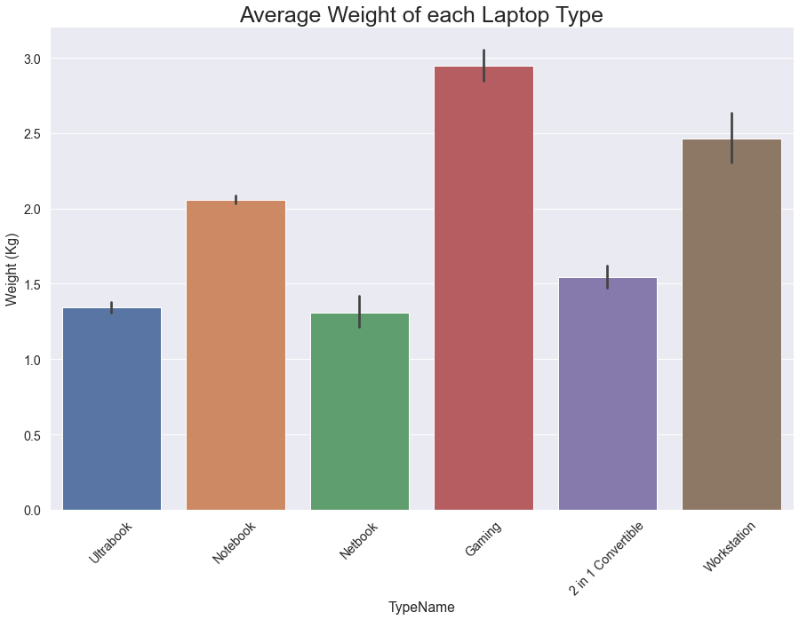

```python
# Drawing a bar graph showing us the Average Weight to each Laptop Type

sns.set(rc={'figure.figsize':(15,10)}, font_scale=1.3)
plt.xticks(rotation=45)
sns.barplot(x=df['TypeName'], y=df['Weight (Kg)']).set_title('Average Weight of each Laptop Type', fontsize = 25)
```

We can see that Gaming Laptops tend to be a bit heavier then the rest, which makes sense since they come with multiple fans and a host of other components to ensure proper cooling and high performance which is required while gaming. Second heaviest laptops are that of Workstation, followed by Notebooks and lightest are Netbooks.

#### Now let's look at the Average price of each Laptop Type

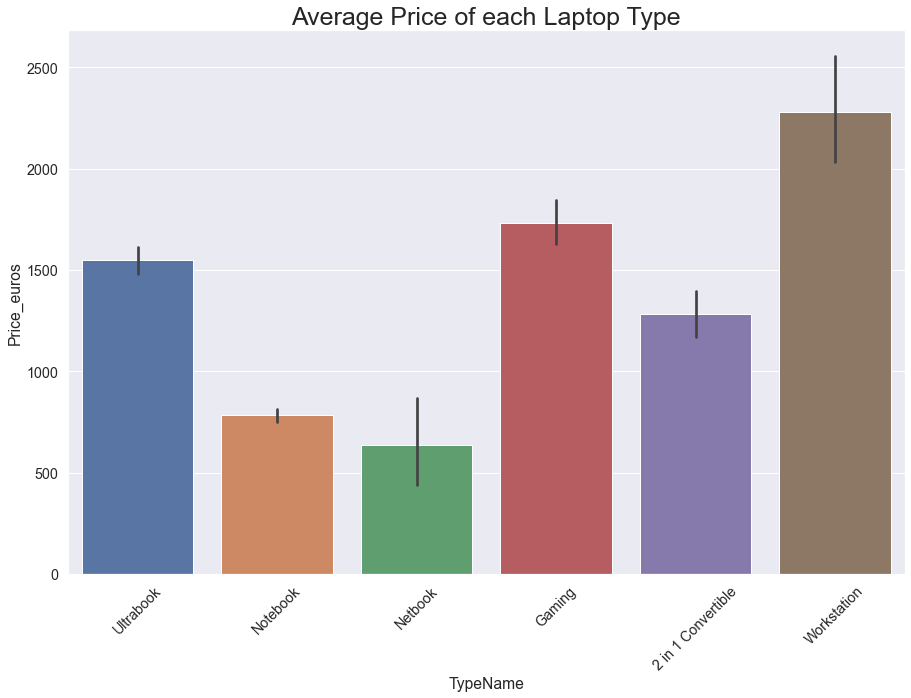

```python
# Drawing a bar graph showing us the Average Price to each Laptop Type

plt.xticks(rotation=45)
sns.barplot(x=df['TypeName'], y=df['Price_euros']).set_title('Average Price of each Laptop Type', fontsize = 25)
```

From the above bar plot we can see that Workstation Laptops tend to be on the costly side, which makes sense cause Workstation laptops, which are used for heavy end workload, are expected to have huge performance with many features and components which is the reason for the increased cost. They are followed by Gaming Laptops which are also expected to have high performance and features for gaming purposes. The lowest cost is that of the Netbook Laptops, these are light performance laptops whose purpose if just to perform small end tasks like document editing, Internet surfing and other not so heavily computation required tasks.

#### Now let us look at the Average Price of each Laptop Manufacturer

```
Company
Acer          626.78
Apple        1564.20
Asus         1104.17
Chuwi         314.30
Dell         1186.07
Fujitsu       729.00
Google       1677.67
HP           1067.77
Huawei       1424.00
LG           2099.00
Lenovo       1086.38
MSI          1728.91
Mediacom      295.00
Microsoft    1612.31
Razer        3346.14
Samsung      1413.44
Toshiba      1267.81
Vero          217.43
Xiaomi       1133.46
Name: Price_euros, dtype: float64
```

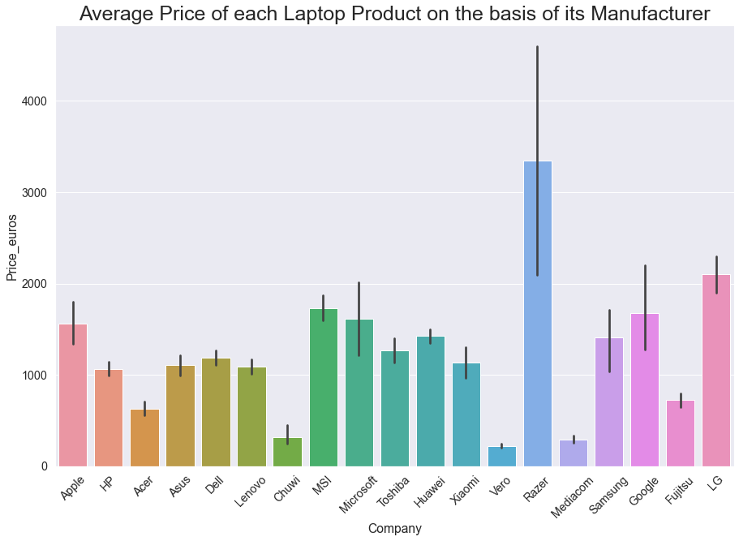

```python
# Drawing a bar graph showing us the Average Price to each Laptop Manufacturer

plt.xticks(rotation=45)
sns.barplot(x=df['Company'], y=df['Price_euros']).set_title('Average Price of each Laptop Product on the basis of its Manufacturer', fontsize = 25)
df.groupby('Company')['Price_euros'].mean()
```

We can see that Razer produced few of the costliest laptops, targeting people who need heavy performance laptops and are ready to compromise with the cost. They are followed by LG, which produced durable laptops with gorgeous displays and MSI, which produces top end gaming laptops. The lowest being Vero, which produces laptops that carter to the basic requirements, like surfing and document editing,etc,., for the people who do not want to spend much on laptops.

#### Now let us look at the Average Price of each laptop based on it's GPU provider

```
Gpu Vendor
AMD        775.65
ARM        659.00
Intel     1008.23
Nvidia    1489.87
Name: Price_euros, dtype: float64
```

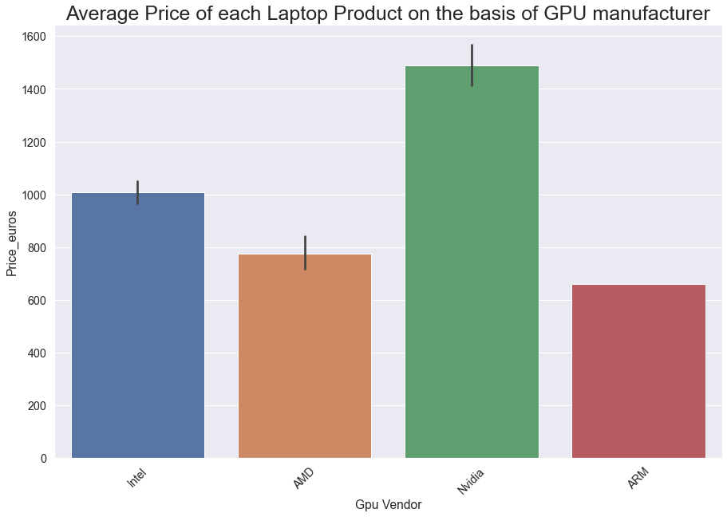

```python
plt.xticks(rotation=45)
sns.barplot(x=df['Gpu Vendor'], y=df['Price_euros']).set_title('Average Price of each Laptop Product on the basis of GPU manufacturer', fontsize = 25)
df.groupby('Gpu Vendor')['Price_euros'].mean()
```

We can see that Nvidia's GPU's are the costliest and the reason is because they produce heavy GPU's suited for various tasks ranging from hardcore gaming to lightweight editing and are quite popular for their speed and efficiency. Nvidia is considered the leader at making GPU's. They are followed by Intel who are the leaders at making CPU chip-sets. We can also notice that that entire GPU market has only 4 players which also makes sense since GPU's too require a heavy capital investment and huge running capital to maintain the infrastructure, which acts as a huge barrier thereby preventing new players from entering the market.